# Analitica ccbd_dm

### Conclusiones del Análisis ccbd_diameter

En esta ocasión, se realiza una exploración de los datos referidos a ccbd_diameter. Podemos observar con y sin outliers la distribución se puede ajustar a Distribución teórica Weibull. Sin embargo, para lograr un mejor estimador de parámetros, es posible solo dejando afuera del estudio a los valores atípicos que se bien son pocos tienen efectos globales al estudio.

Tanto desde el punto de vista de ajustar a una distribución teórica como analizar simplemente entiendo que tiene una distribución suavizada, se observa gráficamente logrado la curvatura similar en distribución paramétrica como no parámetrica. El estudio, al tener la aproximación a su curvatura, busca establecer los estimadores que guíen los estudios posteriores.

```r
### Ubicacion de datos
setwd("C:/hcgalvan/Repositorios/hcgalvan_project/data/union/End")
temp = gsub(".*target.*", "", readLines("seleccionestudio.csv"))
data<-read.table(text=temp, sep=",", header=TRUE)
ccdbdm <-data$ccbd_diameter
```

```r
### Ubicacion de datos
setwd("C:/hcgalvan/Repositorios/hcgalvan_project/data/union/End")
temp = gsub(".*target.*", "", readLines("seleccionestudio.csv"))
data<-read.table(text=temp, sep=",", header=TRUE)
ccdbdm <-data$ccbd_diameter
```

```r
fitData <- function(data, fit="gamma", sample=sample){
 distrib = list()
 numfit <- length(fit)
 results = matrix(0, ncol=5, nrow=numfit)

 for(i in 1:numfit){
if((fit[i] == "gamma") |
     (fit[i] == "poisson") |
     (fit[i] == "weibull") |
     (fit[i] == "exponential") |
     (fit[i] == "logistic") |
     (fit[i] == "normal") |
     (fit[i] == "geometric")
)
  distrib[[i]] = fit[i]
else stop("Provide a valid distribution to fit data" )
 }

 # take a sample of dataset
 n = round(length(data)*sample)
 data = sample(data, size=n, replace=F)

 for(i in 1:numfit) {
  if(distrib[[i]] == "gamma") {
  gf_shape = "gamma"
  fd_g <- fitdistr(data, "gamma")
  est_shape = fd_g$estimate[[1]]
  est_rate = fd_g$estimate[[2]]

  ks = ks.test(data, "pgamma", shape=est_shape, rate=est_rate)

  # add to results
  results[i,] = c(gf_shape, est_shape, est_rate, ks$statistic, ks$p.value)
}

else if(distrib[[i]] == "poisson"){
  gf_shape = "poisson"
  fd_p <- fitdistr(data, "poisson")
  est_lambda = fd_p$estimate[[1]]

  ks = ks.test(data, "ppois", lambda=est_lambda)
  # add to results
  results[i,] = c(gf_shape, est_lambda, "NA", ks$statistic, ks$p.value)
}

else if(distrib[[i]] == "weibull"){
  gf_shape = "weibull"
  fd_w <- fitdistr(data,densfun=dweibull,start=list(scale=1,shape=2))
  est_shape = fd_w$estimate[[1]]
  est_scale = fd_w$estimate[[2]]

  ks = ks.test(data, "pweibull", shape=est_shape, scale=est_scale)
  # add to results
  results[i,] = c(gf_shape, est_shape, est_scale, ks$statistic, ks$p.value)
}

else if(distrib[[i]] == "normal"){
  gf_shape = "normal"
  fd_n <- fitdistr(data, "normal")
  est_mean = fd_n$estimate[[1]]
  est_sd = fd_n$estimate[[2]]

  ks = ks.test(data, "pnorm", mean=est_mean, sd=est_sd)
  # add to results
  results[i,] = c(gf_shape, est_mean, est_sd, ks$statistic, ks$p.value)
}

else if(distrib[[i]] == "exponential"){
  gf_shape = "exponential"
  fd_e <- fitdistr(data, "exponential")
  est_rate = fd_e$estimate[[1]]
  ks = ks.test(data, "pexp", rate=est_rate)
  # add to results
  results[i,] = c(gf_shape, est_rate, "NA", ks$statistic, ks$p.value)
}

else if(distrib[[i]] == "logistic"){
  gf_shape = "logistic"
  fd_l <- fitdistr(data, "logistic")
  est_location = fd_l$estimate[[1]]
  est_scale = fd_l$estimate[[2]]
  ks = ks.test(data, "plogis", location=est_location, scale=est_scale)
  # add to results
  results[i,] = c(gf_shape, est_location, est_scale, ks$statistic,    ks$p.value)
    }
  }
  results = rbind(c("distribution", "param1", "param2", "ks stat", "ks    pvalue"),   results)
  #print(results)
  return(results)
  }
```

#### Tratamiento Ajustado a Distribución y comparativa con/sin outliers

Separamos los datos de la variable de estudio

```r
Control<-(as.numeric(unlist(subset(data, label==1, select=c(ccbd_diameter)))))
Estudio<-(as.numeric(unlist(subset(data, label==0, select=c(ccbd_diameter)))))
```

Ajustamos los outliers en base a Primer barrido.

```r
Q <- quantile(data$ccbd_diameter, probs=c(.25, .75), na.rm = FALSE)
iqr <- IQR(data$ccbd_diameter)
up <-  Q[2]+1.5*iqr # Upper Range
low<- Q[1]-1.5*iqr # Lower Range
datasinout<- subset(data, data$ccbd_diameter > (Q[1] - 1.5*iqr) & data$ccbd_diameter < (Q[2]+1.5*iqr))
```

Ajustamos los outliers en base a Segundor barrido.

```r
Q1 <- quantile(datasinout$ccbd_diameter, probs=c(.25, .75), na.rm = FALSE)
iqr1 <- IQR(datasinout$ccbd_diameter)
up1 <-  Q1[2]+1.5*iqr1 # Upper Range
low1<- Q1[1]-1.5*iqr1 # Lower Range
datasinout1<- subset(datasinout, datasinout$ccbd_diameter > (Q1[1] - 1.5*iqr1) & datasinout$ccbd_diameter < (Q1[2]+1.5*iqr1))
```

Graficamos la evolución y separamos los datos en 2 grupos: Estudio y Control

```
[1] 19.17730  7.96909 15.75940  7.96909 15.75940 19.17730
```

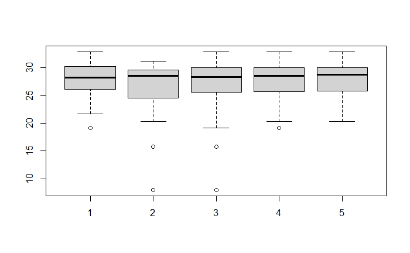

```r
boxplot(Control, Estudio, data$ccbd_diameter, datasinout$ccbd_diameter, datasinout1$ccbd_diameter)$out
```

Graficamos las distribuciones obtenidos.

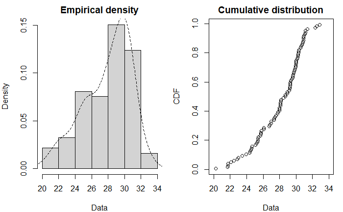

```r
par(mfrow = c(2, 2), mar = c(4, 4, 2, 1))
plotdist(datasinout1$ccbd_diameter, histo=TRUE, demp=TRUE) #completamente ajustado
```

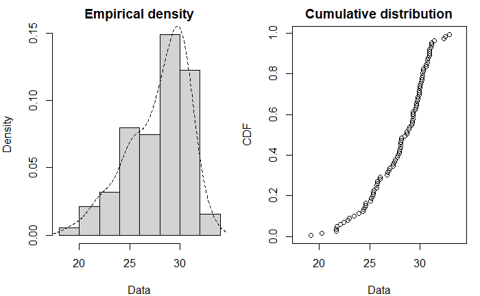

```r
plotdist(datasinout$ccbd_diameter, histo=TRUE, demp=TRUE) # ajustado parcialmente
```

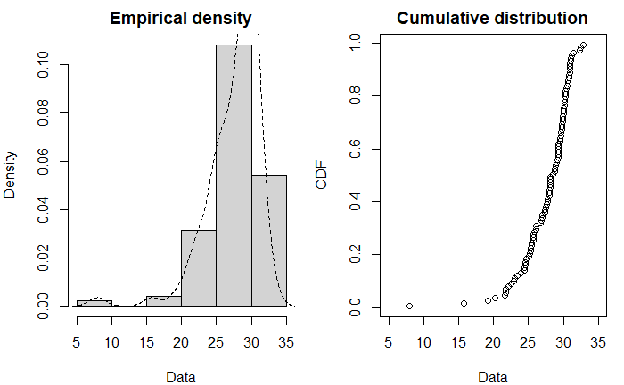

```r
plotdist(data$ccbd_diameter, histo=TRUE, demp=TRUE) # sin ajustes en muestra
```

Realizamos descripcion de los valores descriptivos: Ajuste total, parcial y sin ajuste

```r
summary(datasinout1$ccbd_diameter)
```

```
   Min. 1st Qu.  Median    Mean 3rd Qu.    Max.
  20.27   25.75   28.71   27.93   30.04   32.90
```

```r
summary(datasinout$ccbd_diameter)
```

```
   Min. 1st Qu.  Median    Mean 3rd Qu.    Max.
  19.18   25.74   28.59   27.84   30.04   32.90
```

```r
summary(data$ccbd_diameter)
```

```
   Min. 1st Qu.  Median    Mean 3rd Qu.    Max.
  7.969  25.631  28.321  27.508  30.030  32.900
```

Graficamos la densidad de distribución: Ajuste Total, Parcial y sin ajustes

```
summary statistics
------
min:  20.2675   max:  32.8997
median:  28.7117
mean:  27.93396
estimated sd:  2.834284
estimated skewness:  -0.7110101
estimated kurtosis:  2.760109
```

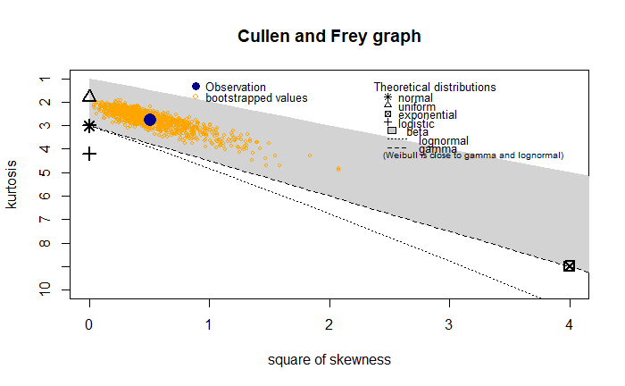

```r
descdist(datasinout1$ccbd_diameter, boot = 1000)
```

```
summary statistics
------
min:  19.1773   max:  32.8997
median:  28.58845
mean:  27.84081
estimated sd:  2.960156
estimated skewness:  -0.8051614
estimated kurtosis:  3.043464
```

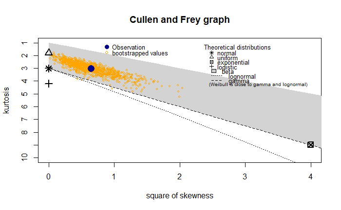

```r
descdist(datasinout$ccbd_diameter, boot = 1000)
```

```
summary statistics
------
min:  7.96909   max:  32.8997
median:  28.321
mean:  27.50796
estimated sd:  3.762872
estimated skewness:  -2.050954
estimated kurtosis:  10.18524
```

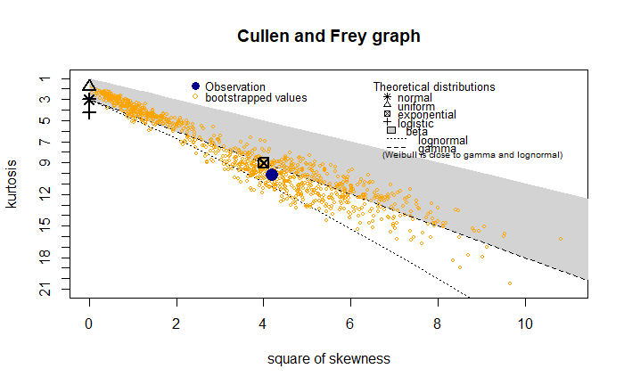

```r
descdist(data$ccbd_diameter, boot = 1000)
```

Ajustamos los datos a la distribución weibull y gamma

```r
summary(total1)
```

```
Fitting of the distribution ' weibull ' by maximum likelihood
Parameters :
```

|  | estimate | Std. Error |
| --- | --- | --- |
| shape | 12.67343 | 1.0668282 |
| scale | 29.14197 | 0.2503927 |

```
Loglikelihood:  -222.2798   AIC:  448.5596   BIC:  453.6248
Correlation matrix:
          shape     scale
shape 1.0000000 0.3053044
scale 0.3053044 1.0000000
```

```r
par(mfrow = c(2, 2), mar = c(4, 4, 2, 1))
plot.legend <- c("Ajuste Total ~Weibull", "Ajuste Parc ~Weibull","Sin Ajuste ~Weibull","Sin Ajuste ~gamma")
denscomp(total, legendtext = plot.legend[1])
denscomp(parcial, legendtext = plot.legend[2])
```

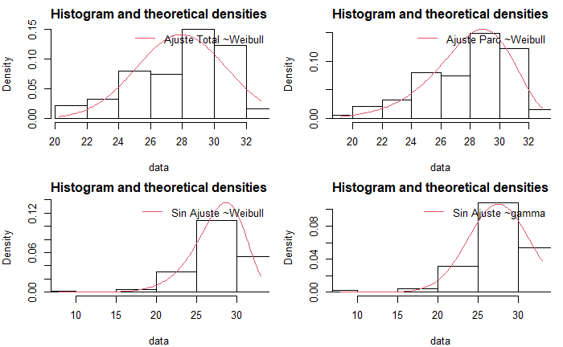

```r
denscomp(sinajuste, legendtext = plot.legend[3])
denscomp(fw, legendtext = plot.legend[4])
```

```r
par(mfrow = c(2, 2), mar = c(4, 4, 2, 1))
plot.legend <- c("Ajuste Total ~Weibull", "Ajuste Parc ~Weibull","Sin Ajuste ~Weibull","Sin Ajuste ~gamma" )
qqcomp(total, legendtext = plot.legend[1])
qqcomp(parcial, legendtext = plot.legend[2])
```

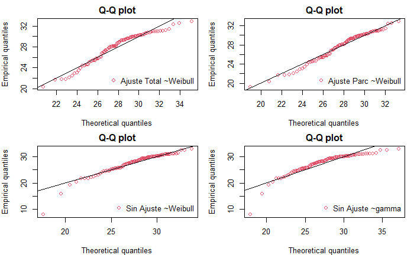

```r
qqcomp(sinajuste, legendtext = plot.legend[3])
qqcomp(fw, legendtext = plot.legend[4])
```

```r
par(mfrow = c(2, 2), mar = c(4, 4, 2, 1))
plot.legend <- c("Ajuste Total ~Weibull", "Ajuste Parc ~Weibull","Sin Ajuste ~Weibull","Sin Ajuste ~gamma")
cdfcomp(total, legendtext = plot.legend[1])
cdfcomp(parcial, legendtext = plot.legend[2])
```

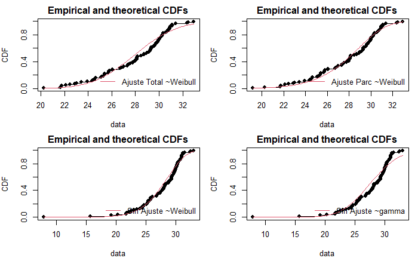

```r
cdfcomp(sinajuste, legendtext = plot.legend[3])
cdfcomp(fw, legendtext = plot.legend[4])
```

```r
par(mfrow = c(2, 2), mar = c(4, 4, 2, 1))
plot.legend <- c("Ajuste Total ~Weibull", "Ajuste Parc ~Weibull","Sin Ajuste ~Weibull","Sin Ajuste ~gamma")
ppcomp(total, legendtext = plot.legend[1])
ppcomp(parcial, legendtext = plot.legend[2])
```

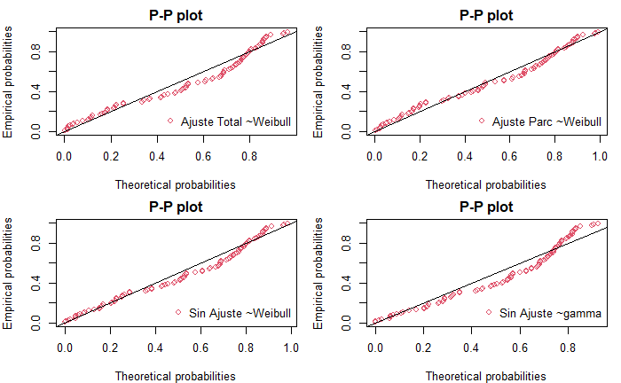

```r
ppcomp(sinajuste, legendtext = plot.legend[3])
ppcomp(fw, legendtext = plot.legend[4])
```

```r
par(mfrow = c(2, 2), mar = c(4, 4, 2, 1))
fw <- fitdist(datasinout$ccbd_diameter, "weibull")
fg <- fitdist(datasinout$ccbd_diameter, "gamma")
fb <- fitdist(datasinout$ccbd_diameter, "lnorm")
plot.legend <- c("weibull", "gamma", "lnorm")
denscomp(list(fw, fg, fb), legendtext = plot.legend)
qqcomp(list(fw, fg, fb), legendtext = plot.legend)
```

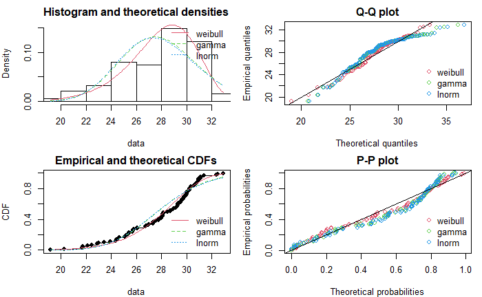

```r
cdfcomp(list(fw, fg, fb), legendtext = plot.legend)
ppcomp(list(fw, fg, fb), legendtext = plot.legend)
```

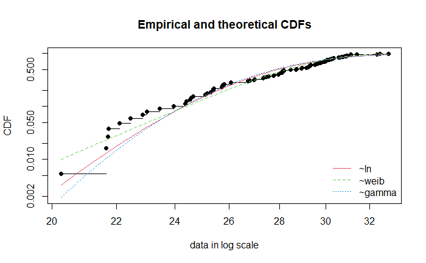

```r
library(actuar)

ATV1 <- datasinout1$ccbd_diameter
datos1.l<-fitdist(ATV1, "norm")
datos1.w<-fitdist(ATV1, "weibull")
datos1.g<-fitdist(ATV1, "gamma")
cdfcomp(list(datos1.l, datos1.w, datos1.g), xlogscale = TRUE,
        ylogscale = TRUE, legendtext = c("~ln","~weib","~gamma"))
```